# Coursework Report

*N* removed NAs: 2

*N* removed typo: 1

*N* removed <18: 24

*N* total clean: 123

| Group | *N* | *M*<sub>age</sub> | *M*<sub>rating</sub> |
| --- | --- | --- | --- |
| Control | 61 | 21.48 | 5.22 |
| Experim | 62 | 21.16 | 6.46 |

**Main analysis results**

*t*(121) = -10.61, *p* < .001

[interactive chart not shown]

[figure not shown]

[interactive chart not shown]

# Coursework Report

Analysing Data, Spring 2020

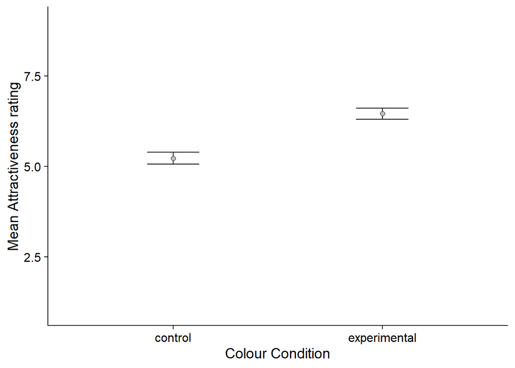

# Methods

## Design

The conceptual hypothesis of the following study focuses on if colour influences attractiveness. This hypothesis is operationalised, in order to make an operational hypothesis, which specifically looks at how the colour of the frame can influence the mean attractiveness rating of the moderately attractive man used in the study. Further operationalised variables include: creating two conditions with the same picture, the experimental condition which used a red frame (the colour red being the independant categorical variable in the present study); and the control condition, which used a neutral white frame. Also a rating scale, with three questions on attractiveness (which is the continuous variable): “how attractive do you think the person is?”; “how pleasant is this person to look at?; and”if I were to meet the person in this picture face to face I would think this person is attractive". The rating scale ranges from 1-9, 1 being the lowest score, and 9 being the highest, and the 3 questions are averaged to get a composite score. After the experiment has taken place, and the data is collected, a two tailed t-test will be used, in order to check the significance of the results in relation to the operationalised hypothesis.

# Results

Our investigation assesses if participants ratings of attractiveness, for a moderately attractive man, could be influenced by the colour of the photoframe the image is in. The results and analysis indicate that, as predicted, the control condition had a lower overall mean rating of attractiveness (*M* = 5.22) compared to experimental condition (*M* = 6.46). Therefore this difference in means was significant (*M*<sub>diff</sub> = -1.24, 95% CI [-1.47, -1.01], *t* (121) = -10.61, *p* = 0).

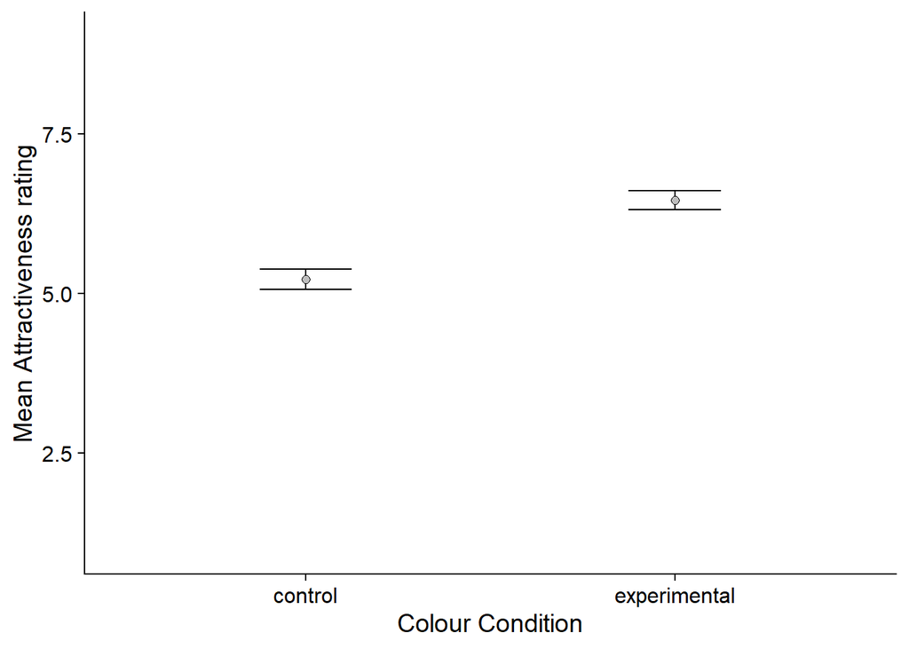

Table 1 * Descriptive statistic by Question 1*

| Question 1 | *N*) | % | *M*<sub>AGE</sub> | *SD<sub>AGE</sub> |
| --- | --- | --- | --- | --- |
| 2 | 1 | 0.81 | 25.00 | NA |
| 3 | 6 | 4.88 | 22.00 | 1.26 |
| 4 | 20 | 16.26 | 21.20 | 2.50 |
| 5 | 28 | 22.76 | 21.71 | 1.72 |
| 6 | 37 | 30.08 | 21.03 | 2.19 |
| 7 | 18 | 14.63 | 21.06 | 2.44 |
| 8 | 9 | 7.32 | 20.78 | 2.39 |
| 9 | 4 | 3.25 | 22.25 | 1.89 |

Table 1 * Descriptive statistic by Question 2*

| Question 2 | *N*) | % | *M*<sub>AGE</sub> | *SD<sub>AGE</sub> |
| --- | --- | --- | --- | --- |
| 2 | 1 | 0.81 | 20.00 | NA |
| 3 | 6 | 4.88 | 22.00 | 2.53 |
| 4 | 18 | 14.63 | 21.33 | 2.09 |
| 5 | 23 | 18.70 | 21.48 | 2.17 |
| 6 | 35 | 28.46 | 21.97 | 2.12 |
| 7 | 30 | 24.39 | 20.67 | 2.01 |
| 8 | 8 | 6.50 | 20.38 | 2.50 |
| 9 | 2 | 1.63 | 20.00 | 1.41 |

Table 1 * Descriptive statistic by Question 3*

| Question 3 | *N*) | % | *M*<sub>AGE</sub> | *SD<sub>AGE</sub> |
| --- | --- | --- | --- | --- |
| 3 | 4 | 3.25 | 22.00 | 2.71 |
| 4 | 10 | 8.13 | 20.50 | 1.72 |
| 5 | 23 | 18.70 | 21.87 | 2.67 |
| 6 | 42 | 34.15 | 21.57 | 1.80 |
| 7 | 26 | 21.14 | 21.31 | 2.36 |
| 8 | 12 | 9.76 | 20.33 | 1.83 |
| 9 | 6 | 4.88 | 20.33 | 1.97 |

Table 1 * Descriptive statistic by Mean Attractiveness Rating*

| Mean Attractiveness | *N*) | % | *M*<sub>AGE</sub> | *SD<sub>AGE</sub> |
| --- | --- | --- | --- | --- |
| 3.67 | 1 | 0.81 | 25.00 | NA |
| 4.00 | 3 | 2.44 | 20.00 | 2.00 |
| 4.33 | 4 | 3.25 | 21.50 | 1.29 |
| 4.67 | 8 | 6.50 | 22.38 | 2.72 |
| 5.00 | 11 | 8.94 | 22.55 | 2.02 |
| 5.33 | 18 | 14.63 | 20.94 | 1.55 |
| 5.67 | 19 | 15.45 | 21.16 | 2.17 |
| 6.00 | 13 | 10.57 | 21.85 | 1.91 |
| 6.33 | 14 | 11.38 | 21.50 | 2.62 |
| 6.67 | 17 | 13.82 | 20.71 | 2.23 |
| 7.00 | 7 | 5.69 | 21.14 | 2.54 |
| 7.33 | 4 | 3.25 | 19.75 | 1.50 |
| 7.67 | 3 | 2.44 | 20.67 | 1.53 |
| 8.33 | 1 | 0.81 | 19.00 | NA |

```
##
##  Two Sample t-test
##
## data:  attract_mean by GROUP
## t = -10.609, df = 121, p-value < 0.00000000000000022
## alternative hypothesis: true difference in means is not equal to 0
## 95 percent confidence interval:
##  -1.469503 -1.007317
## sample estimates:
##      mean in group control mean in group experimental
##                   5.218579                   6.456989
```

# Discussion

In order to effectively discuss the following findings, it is important to refer back to the hypothesis that the study examined, which was looking at how the colour of the frame influenced the mean attractiveness rating of the moderately attractive man. The results indicate that the red frame, the independent variable of this study, did in fact cause an increase in mean attractiveness rating by the participants, compared to the control which was a white frame. These findings suggest that the colour red does have a significant influence on perceived attractiveness, suggesting a possible association between colour and attraction.

In terms of our results compared to other research, the findings in this study are parallel to the effects produced in the original study which this present research is inspired from. In Elliot et al’s (2010) experiment he also found significant support for the “red effect and the mechanism responsible for it”, using a participant base from 4 different countries (both east and west of the world) and with a range of different control colours and targeted men. Elliot did not find the same effect when the gender roles were reversed in the experiment, and as the present study did not examine gender differences, so the suggested consensus is that this is an effect only present when women are rating attraction of men, highlighting a potential difference in the perception of attractiveness between genders. For example, females might have more of a preference for aesthetic and external attractiveness, such as being well dressed in pleasant colours, which might not have as much of an influence on men overall.

However, the findings of this study and Elliot et al’s (2010) research is not consistently agreed upon in other experiments. One more recent study (Wagge et al, 2019) conducted a meta-analysis of 9 student replication projects of Elliot’s original study, which showed no significant effect of backgrounds with the colour red compared to neutral colours, on perceived or sexual attractiveness. Another researcher (Francis, 2013) in his statistical analysis of Elliot’s study and its replications, states “the experiments lack sufficient power to support these claims” suggesting that potential null findings were not reported, ultimately having publication bias. This suggests that Elliot’s study has potential issues with replication, which ultimately decreases the validity of his findings and our own. Therefore, the opinion on the red-effect and its influence on perceived attractiveness is conflicting across different research, and needs a more vigorous and controlled experimental research design.

Considering the strengths and limitations mentioned above, the effectiveness of the red-effect is not as simple as if it is or isn’t, due to the conflicting nature of the research on the topic. What this overall suggests, is that the red-effect although not universal, may be a factor in attractiveness that affects some people (such as individuals who value being well dressed and colour coordination) and does not affect others, its effectiveness being dependant on the individual and their values in attraction. In order to gain a fuller perspective on the effect of the colour red in perceived attractiveness, there needs to be further research, which focuses on both those it effects and those it doesn’t, looking for differences between the two. For example, researchers could introduce a questionnaire pre or post experiment that asks a range of questions surrounding different factors in attraction (i.e. physical attractiveness, dress sense, personality, etc) in order to determine what the individual specifically finds attractive; comparing to the results of the experiment and other participants.

Ultimately, the findings from this study support Elliot’s original study, which highlights the red-effect and it’s influence on attractiveness. However, this is conflicted and lessened in validity by opposing research that claims to find no effect. Therefore, in order to gain a more concrete understanding, further research with more detailed and vigorous measures is required, before any universal or representative claims about the red-effect can be made.

# References

Elliot, A., Niesta Kayser, D., Greitemeyer, T., Lichtenfeld, S., Gramzow, R., Maier, M., & Liu, H. (2010). Red, Rank, and Romance in Women Viewing Men. Journal of Experimental Psychology: General, 139(3), 399-417.

Francis, G. (2013). Publication Bias in “Red, Rank, and Romance in Women Viewing Men,” by Elliot Et Al. (2010), 142(1), 292-296.

Wagge, J. R., Baciu, C., Banas, K., Nadler, J. T., Schwarz, S., Weisberg, Y., … & Grahe, J. (2019). A demonstration of the Collaborative Replication and Education Project: replication attempts of the red-romance effect.